# BellaBeat

Exploratory Data Analysis for a Wellness Company

Kshitija Hire

Friday, August 27 2021

```r
#install.packages("tidyverse")
```

Load the data wrangling package here.

```r
library(tidyverse)
library(lubridate)
```

### LOADING AND VIEWING THE DATA

Let’s load the data

```r
daily_activity <- read_csv("data/dailyActivity_merged.csv")
head(daily_activity, n=10)
```

```
## # A tibble: 10 × 15
##            Id ActivityDate TotalSteps TotalDistance TrackerDistance LoggedActivitie…
##         <dbl> <chr>             <dbl>         <dbl>           <dbl>            <dbl>
##  1 1503960366 4/12/2016         13162          8.5             8.5                 0
##  2 1503960366 4/13/2016         10735          6.97            6.97                0
##  3 1503960366 4/14/2016         10460          6.74            6.74                0
##  4 1503960366 4/15/2016          9762          6.28            6.28                0
##  5 1503960366 4/16/2016         12669          8.16            8.16                0
##  6 1503960366 4/17/2016          9705          6.48            6.48                0
##  7 1503960366 4/18/2016         13019          8.59            8.59                0
##  8 1503960366 4/19/2016         15506          9.88            9.88                0
##  9 1503960366 4/20/2016         10544          6.68            6.68                0
## 10 1503960366 4/21/2016          9819          6.34            6.34                0
## # … with 9 more variables: VeryActiveDistance <dbl>,
## #   ModeratelyActiveDistance <dbl>, LightActiveDistance <dbl>,
## #   SedentaryActiveDistance <dbl>, VeryActiveMinutes <dbl>,
## #   FairlyActiveMinutes <dbl>, LightlyActiveMinutes <dbl>,
## #   SedentaryMinutes <dbl>, Calories <dbl>
```

```r
str(daily_activity)
```

```
## spec_tbl_df [940 × 15] (S3: spec_tbl_df/tbl_df/tbl/data.frame)
##  $ Id                      : num [1:940] 1.5e+09 1.5e+09 1.5e+09 1.5e+09 1.5e+09 ...
##  $ ActivityDate            : chr [1:940] "4/12/2016" "4/13/2016" "4/14/2016" "4/15/2016" ...
##  $ TotalSteps              : num [1:940] 13162 10735 10460 9762 12669 ...
##  $ TotalDistance           : num [1:940] 8.5 6.97 6.74 6.28 8.16 ...
##  $ TrackerDistance         : num [1:940] 8.5 6.97 6.74 6.28 8.16 ...
##  $ LoggedActivitiesDistance: num [1:940] 0 0 0 0 0 0 0 0 0 0 ...
##  $ VeryActiveDistance      : num [1:940] 1.88 1.57 2.44 2.14 2.71 ...
##  $ ModeratelyActiveDistance: num [1:940] 0.55 0.69 0.4 1.26 0.41 ...
##  $ LightActiveDistance     : num [1:940] 6.06 4.71 3.91 2.83 5.04 ...
##  $ SedentaryActiveDistance : num [1:940] 0 0 0 0 0 0 0 0 0 0 ...
##  $ VeryActiveMinutes       : num [1:940] 25 21 30 29 36 38 42 50 28 19 ...
##  $ FairlyActiveMinutes     : num [1:940] 13 19 11 34 10 20 16 31 12 8 ...
##  $ LightlyActiveMinutes    : num [1:940] 328 217 181 209 221 164 233 264 205 211 ...
##  $ SedentaryMinutes        : num [1:940] 728 776 1218 726 773 ...
##  $ Calories                : num [1:940] 1985 1797 1776 1745 1863 ...
##  - attr(*, "spec")=
##   .. cols(
##   ..   Id = col_double(),
##   ..   ActivityDate = col_character(),
##   ..   TotalSteps = col_double(),
##   ..   TotalDistance = col_double(),
##   ..   TrackerDistance = col_double(),
##   ..   LoggedActivitiesDistance = col_double(),
##   ..   VeryActiveDistance = col_double(),
##   ..   ModeratelyActiveDistance = col_double(),
##   ..   LightActiveDistance = col_double(),
##   ..   SedentaryActiveDistance = col_double(),
##   ..   VeryActiveMinutes = col_double(),
##   ..   FairlyActiveMinutes = col_double(),
##   ..   LightlyActiveMinutes = col_double(),
##   ..   SedentaryMinutes = col_double(),
##   ..   Calories = col_double()
##   .. )
##  - attr(*, "problems")=<externalptr>
```

### DATA CLEANING

```r
# changing the Date format
daily_activity <- daily_activity %>%
  rename(Date = ActivityDate) %>%
  mutate(Date = as.Date(Date, format = "%m/%d/%y"))
  #dmy(Date)

daily_activity
```

```
## # A tibble: 940 × 15
##            Id Date       TotalSteps TotalDistance TrackerDistance LoggedActivitie…
##         <dbl> <date>          <dbl>         <dbl>           <dbl>            <dbl>
##  1 1503960366 2020-04-12      13162          8.5             8.5                 0
##  2 1503960366 2020-04-13      10735          6.97            6.97                0
##  3 1503960366 2020-04-14      10460          6.74            6.74                0
##  4 1503960366 2020-04-15       9762          6.28            6.28                0
##  5 1503960366 2020-04-16      12669          8.16            8.16                0
##  6 1503960366 2020-04-17       9705          6.48            6.48                0
##  7 1503960366 2020-04-18      13019          8.59            8.59                0
##  8 1503960366 2020-04-19      15506          9.88            9.88                0
##  9 1503960366 2020-04-20      10544          6.68            6.68                0
## 10 1503960366 2020-04-21       9819          6.34            6.34                0
## # … with 930 more rows, and 9 more variables: VeryActiveDistance <dbl>,
## #   ModeratelyActiveDistance <dbl>, LightActiveDistance <dbl>,
## #   SedentaryActiveDistance <dbl>, VeryActiveMinutes <dbl>,
## #   FairlyActiveMinutes <dbl>, LightlyActiveMinutes <dbl>,
## #   SedentaryMinutes <dbl>, Calories <dbl>
```

```r
# Dropping unwanted columns
daily_activity <-  daily_activity %>%
  select(-c(TrackerDistance, SedentaryActiveDistance))
daily_activity
```

```
## # A tibble: 940 × 13
##            Id Date       TotalSteps TotalDistance LoggedActivitie… VeryActiveDista…
##         <dbl> <date>          <dbl>         <dbl>            <dbl>            <dbl>
##  1 1503960366 2020-04-12      13162          8.5                 0             1.88
##  2 1503960366 2020-04-13      10735          6.97                0             1.57
##  3 1503960366 2020-04-14      10460          6.74                0             2.44
##  4 1503960366 2020-04-15       9762          6.28                0             2.14
##  5 1503960366 2020-04-16      12669          8.16                0             2.71
##  6 1503960366 2020-04-17       9705          6.48                0             3.19
##  7 1503960366 2020-04-18      13019          8.59                0             3.25
##  8 1503960366 2020-04-19      15506          9.88                0             3.53
##  9 1503960366 2020-04-20      10544          6.68                0             1.96
## 10 1503960366 2020-04-21       9819          6.34                0             1.34
## # … with 930 more rows, and 7 more variables: ModeratelyActiveDistance <dbl>,
## #   LightActiveDistance <dbl>, VeryActiveMinutes <dbl>,
## #   FairlyActiveMinutes <dbl>, LightlyActiveMinutes <dbl>,
## #   SedentaryMinutes <dbl>, Calories <dbl>
```

```r
#Calculate unique number of participants
daily_activity %>% count(Id)
```

```
## # A tibble: 33 × 2
##            Id     n
##         <dbl> <int>
##  1 1503960366    31
##  2 1624580081    31
##  3 1644430081    30
##  4 1844505072    31
##  5 1927972279    31
##  6 2022484408    31
##  7 2026352035    31
##  8 2320127002    31
##  9 2347167796    18
## 10 2873212765    31
## # … with 23 more rows
```

### DATA EXPLORATION

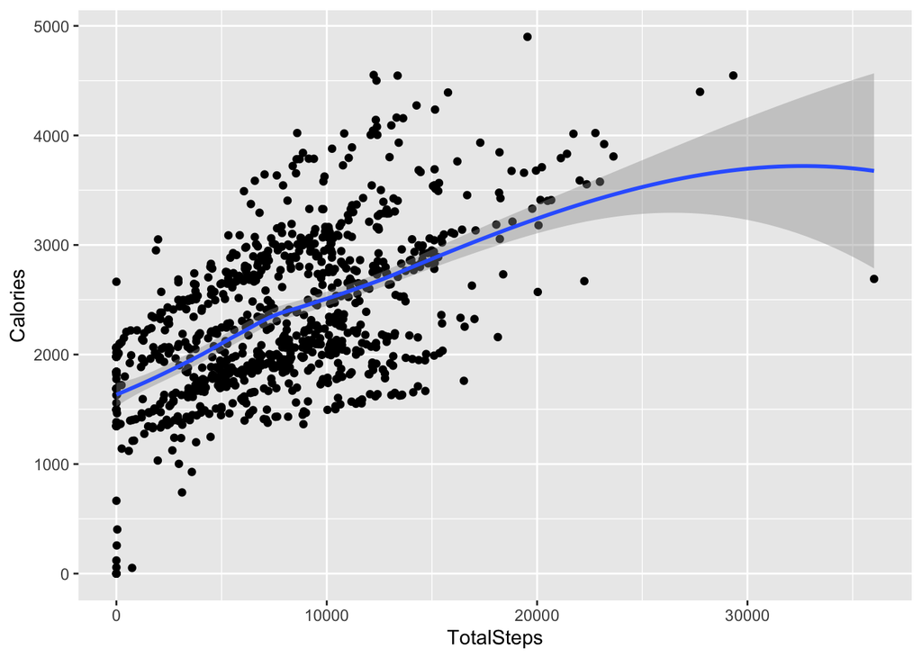

```r
daily_activity %>%
  ggplot(aes(x = TotalSteps,
             y = Calories)) +
  geom_point()+
  geom_smooth()
```

There is an evident positive relation between the total number of steps taken by a participant and the calories burned by them. But, it is not the only reason for their burning calories as the plot is quite scattered.

For example, Lets take 10,000 steps. The calories burned for one participant are 1500 and for other, it is 4000. Which is a huge difference.

Let’s explore in detail what other factors come into play into burning more calories for the same number of steps taken.

```r
daily_activity <- daily_activity %>%
  drop_na() %>%
  mutate(Dist_Category = ifelse(TotalDistance < 4, 'Less than 4 miles',
                         ifelse(TotalDistance >= 4 & TotalDistance <= 7, 'Between 4 and 7 miles',
                         'More than 7 miles'))) %>%
mutate(Dist_Category = factor(Dist_Category, levels = c("Less than 4 miles", "Between 4 and 7 miles", "More than 7 miles")))

daily_activity
```

```
## # A tibble: 940 × 14
##            Id Date       TotalSteps TotalDistance LoggedActivitie… VeryActiveDista…
##         <dbl> <date>          <dbl>         <dbl>            <dbl>            <dbl>
##  1 1503960366 2020-04-12      13162          8.5                 0             1.88
##  2 1503960366 2020-04-13      10735          6.97                0             1.57
##  3 1503960366 2020-04-14      10460          6.74                0             2.44
##  4 1503960366 2020-04-15       9762          6.28                0             2.14
##  5 1503960366 2020-04-16      12669          8.16                0             2.71
##  6 1503960366 2020-04-17       9705          6.48                0             3.19
##  7 1503960366 2020-04-18      13019          8.59                0             3.25
##  8 1503960366 2020-04-19      15506          9.88                0             3.53
##  9 1503960366 2020-04-20      10544          6.68                0             1.96
## 10 1503960366 2020-04-21       9819          6.34                0             1.34
## # … with 930 more rows, and 8 more variables: ModeratelyActiveDistance <dbl>,
## #   LightActiveDistance <dbl>, VeryActiveMinutes <dbl>,
## #   FairlyActiveMinutes <dbl>, LightlyActiveMinutes <dbl>,
## #   SedentaryMinutes <dbl>, Calories <dbl>, Dist_Category <fct>
```

```r
daily_activity <- daily_activity %>%
  drop_na() %>%
  mutate(TotalSteps_Category = ifelse(TotalSteps < 6000, 'Less than 6k steps',
                         ifelse(TotalSteps >= 6000 & TotalSteps <= 10000, 'Between 6k and 10k steps',
                         'More than 10k'))) %>%
mutate(TotalSteps_Category = factor(TotalSteps_Category, levels = c("Less than 6k steps", "Between 6k and 10k steps", "More than 10k")))

daily_activity
```

```
## # A tibble: 940 × 15
##            Id Date       TotalSteps TotalDistance LoggedActivitie… VeryActiveDista…
##         <dbl> <date>          <dbl>         <dbl>            <dbl>            <dbl>
##  1 1503960366 2020-04-12      13162          8.5                 0             1.88
##  2 1503960366 2020-04-13      10735          6.97                0             1.57
##  3 1503960366 2020-04-14      10460          6.74                0             2.44
##  4 1503960366 2020-04-15       9762          6.28                0             2.14
##  5 1503960366 2020-04-16      12669          8.16                0             2.71
##  6 1503960366 2020-04-17       9705          6.48                0             3.19
##  7 1503960366 2020-04-18      13019          8.59                0             3.25
##  8 1503960366 2020-04-19      15506          9.88                0             3.53
##  9 1503960366 2020-04-20      10544          6.68                0             1.96
## 10 1503960366 2020-04-21       9819          6.34                0             1.34
## # … with 930 more rows, and 9 more variables: ModeratelyActiveDistance <dbl>,
## #   LightActiveDistance <dbl>, VeryActiveMinutes <dbl>,
## #   FairlyActiveMinutes <dbl>, LightlyActiveMinutes <dbl>,
## #   SedentaryMinutes <dbl>, Calories <dbl>, Dist_Category <fct>,
## #   TotalSteps_Category <fct>
```

```r
summary(daily_activity)
```

```
##        Id                 Date              TotalSteps    TotalDistance
##  Min.   :1.504e+09   Min.   :2020-04-12   Min.   :    0   Min.   : 0.000
##  1st Qu.:2.320e+09   1st Qu.:2020-04-19   1st Qu.: 3790   1st Qu.: 2.620
##  Median :4.445e+09   Median :2020-04-26   Median : 7406   Median : 5.245
##  Mean   :4.855e+09   Mean   :2020-04-26   Mean   : 7638   Mean   : 5.490
##  3rd Qu.:6.962e+09   3rd Qu.:2020-05-04   3rd Qu.:10727   3rd Qu.: 7.713
##  Max.   :8.878e+09   Max.   :2020-05-12   Max.   :36019   Max.   :28.030
##  LoggedActivitiesDistance VeryActiveDistance ModeratelyActiveDistance
##  Min.   :0.0000           Min.   : 0.000     Min.   :0.0000
##  1st Qu.:0.0000           1st Qu.: 0.000     1st Qu.:0.0000
##  Median :0.0000           Median : 0.210     Median :0.2400
##  Mean   :0.1082           Mean   : 1.503     Mean   :0.5675
##  3rd Qu.:0.0000           3rd Qu.: 2.053     3rd Qu.:0.8000
##  Max.   :4.9421           Max.   :21.920     Max.   :6.4800
##  LightActiveDistance VeryActiveMinutes FairlyActiveMinutes LightlyActiveMinutes
##  Min.   : 0.000      Min.   :  0.00    Min.   :  0.00      Min.   :  0.0
##  1st Qu.: 1.945      1st Qu.:  0.00    1st Qu.:  0.00      1st Qu.:127.0
##  Median : 3.365      Median :  4.00    Median :  6.00      Median :199.0
##  Mean   : 3.341      Mean   : 21.16    Mean   : 13.56      Mean   :192.8
##  3rd Qu.: 4.782      3rd Qu.: 32.00    3rd Qu.: 19.00      3rd Qu.:264.0
##  Max.   :10.710      Max.   :210.00    Max.   :143.00      Max.   :518.0
##  SedentaryMinutes    Calories                  Dist_Category
##  Min.   :   0.0   Min.   :   0   Less than 4 miles    :354
##  1st Qu.: 729.8   1st Qu.:1828   Between 4 and 7 miles:282
##  Median :1057.5   Median :2134   More than 7 miles    :304
##  Mean   : 991.2   Mean   :2304
##  3rd Qu.:1229.5   3rd Qu.:2793
##  Max.   :1440.0   Max.   :4900
##                TotalSteps_Category
##  Less than 6k steps      :366
##  Between 6k and 10k steps:271
##  More than 10k           :303
##
##
##
```

We could observe : The average women seems to walk more number of steps but eventually cover less distance.

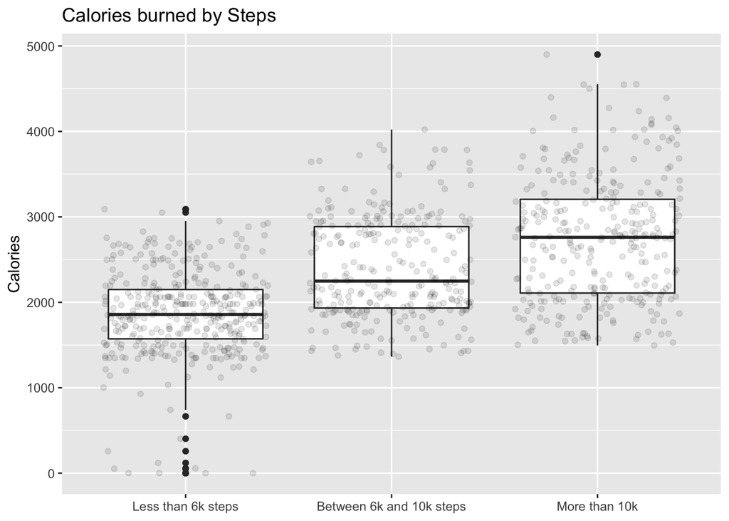

```r
daily_activity %>%
ggplot(aes(TotalSteps_Category,Calories)) +
  geom_boxplot() +
  geom_jitter(alpha = 0.1)+

    labs(title="Calories burned by Steps",x=NULL)
```

Before moving on to additional factors involved in burning more calories with less or the same number of steps, let’s take another look at the link between Calories Burned and Steps Taken.

There is an even distribution of women walking from less than 6k steps to more than 10k.

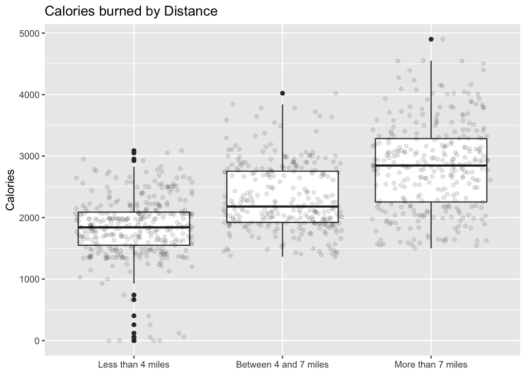

```r
daily_activity %>%
ggplot(aes(Dist_Category,Calories)) +
  geom_boxplot() +
  geom_jitter(alpha = 0.1)+

    labs(title="Calories burned by Distance",x=NULL)
```

We also notice, For the majority of the time, many women walk fewer than 10 miles each day. We can assume they have a set path that they take every day, either for work or as part of their daily fitness routine.

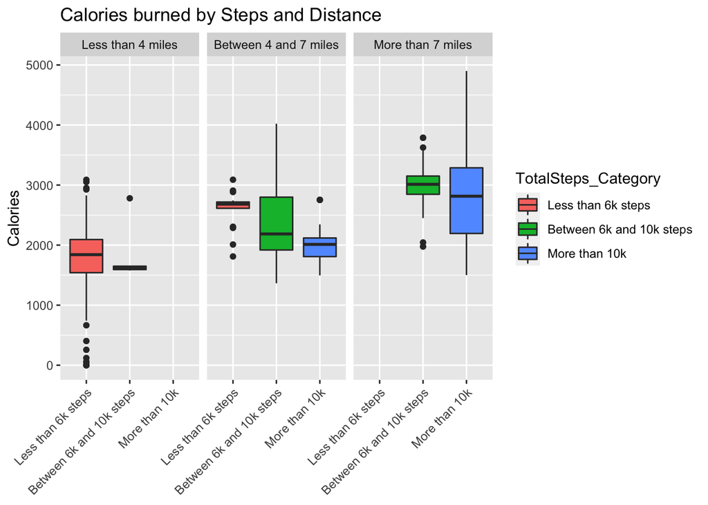

```r
daily_activity %>%
ggplot(aes(TotalSteps_Category,Calories,fill=TotalSteps_Category)) +
  geom_boxplot() +
    facet_wrap(~Dist_Category)+

    labs(title="Calories burned by Steps and Distance",x=NULL) +
  theme(axis.text.x = element_text(angle = 45, hjust = 1))
```

Different distance, Different number of steps:

“More than 10k steps” in “between 4 and 7 miles” and “less than 6k steps” in “less than 4 miles” both burn the same amount of calories.

Same distance, Different number of steps:

In “More than 7 miles”, more calories are burned with less number of steps (between 6-10k) than more than 10k.

This reinforces the idea that speed is one of the most important factor to burn calories.